# Assignment 3

DATA 311 - Machine Learning

Author

Maxim Storozhuk (40965642)

# Exercise 1

```r
library(glmnet)    # For Ridge and Lasso regression
library(caret)     # For data splitting and evaluation
library(tidyverse) # For data manipulation and visualization
library(randomForest)
library(rpart)
library(rpart.plot)
library(knitr)

data <- read.csv("assignmentData/A3/datasalaries.csv")
str(data)
```

```
'data.frame':   7517 obs. of  7 variables:
 $ company          : chr  "Google" "Microsoft" "Google" "Microsoft" ...
 $ salary           : int  400000 136000 337000 222000 310000 620000 180000 210000 142000 242000 ...
 $ yearsofexperience: int  5 3 6 4 15 19 1 4 0 2 ...
 $ yearsatcompany   : int  5 2 6 4 3 7 1 1 0 2 ...
 $ gender           : chr  "Male" "Male" "Male" "Male" ...
 $ Race             : chr  "Asian" "Two Or More" "Asian" "Asian" ...
 $ Education        : chr  "PhD" "Bachelor's Degree" "Bachelor's Degree" "Master's Degree" ...
```

```r
#Data seems to be properly formatted. Check for N/As
summary(data)
```

```
   company              salary        yearsofexperience yearsatcompany
 Length:7517        Min.   :  12000   Min.   : 0.000    Min.   : 0.000
 Class :character   1st Qu.: 164000   1st Qu.: 3.000    1st Qu.: 0.000
 Mode  :character   Median : 212000   Median : 6.000    Median : 2.000
                    Mean   : 241483   Mean   : 7.324    Mean   : 2.559
                    3rd Qu.: 290000   3rd Qu.:10.000    3rd Qu.: 4.000
                    Max.   :4980000   Max.   :39.000    Max.   :28.000
    gender              Race            Education
 Length:7517        Length:7517        Length:7517
 Class :character   Class :character   Class :character
 Mode  :character   Mode  :character   Mode  :character
```

All of the data is properly formatted, and there are no N/A values. There are 7517 observations.

# Exercise 2

```r
set.seed(40965642) #student number as seed for reproducibility
n <- nrow(data) #number of rows in data
#get all the indices in the corresponding storage containers
train_indices <- sample(1:n, size = round(n*0.5)) #0.5 because 50% of data should be in training set
train_data <- data[train_indices, ]
test_data <- data[-train_indices, ]
#check to make sure split was done properly
nrow(train_data)
```

```
[1] 3758
```

```r
nrow(test_data)
```

```
[1] 3759
```

# Exercise 3

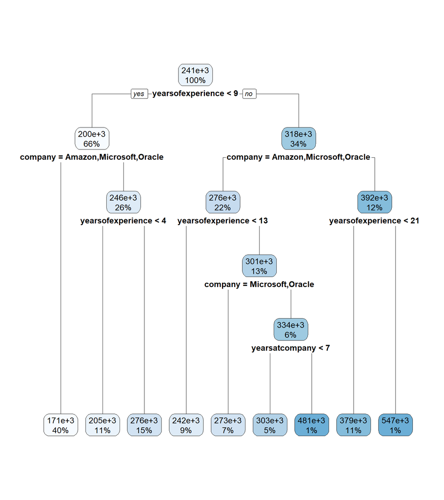

```r
modelE3 <- rpart(salary ~ ., data = train_data, method = "anova")
rpart.plot(modelE3)
```

**Decision Node 1: yearsofexperience < 9**

Employees with less than 9 years of experience are expected to have a lower salary, so they are sent to the left side of the tree.

Employees with 9 or more years of experience are expected to have a higher salary, so they are sent to the right side of the tree.

**Decision Node 2: company = Amazon, Microsoft, Oracle** (first node on left side)

Employees who work at Amazon, Microsoft, or Oracle are expected to have a lower salary than those who work at a different company, so they are sent to the left side of this subset of the tree.

Employees who work at a company other than Amazon, Microsoft, or Oracle are expected to have a higher salary than those who do, so they are sent to the right side of this subset of the tree.

**Decision Node 3: company = Amazon, Microsoft, Oracle** (first node on right side)

Employees who work at Amazon, Microsoft, or Oracle are expected to have a lower salary than those who work at a different company, so they are sent to the left side of this subset of the tree.

Employees who work at a company other than Amazon, Microsoft, or Oracle are expected to have a higher salary than those who do, so they are sent to the right side of this subset of the tree.

# Exercise 4

```r
predictModelE3 <- predict(modelE3, newdata = test_data)
mseE3 <- mean((predictModelE3 - test_data$salary)^2)
rmseE3 <- sqrt(mseE3)
rmseE3
```

```
[1] 149356
```

# Exercise 5

```r
set.seed(40965642)
modelE5 <- randomForest(salary ~ ., data = train_data, ntree = 500, importance = TRUE)
```

# Exercise 6

```r
predictModelE5 <- predict(modelE5, newdata = test_data)
mseE5 <- mean((predictModelE5 - test_data$salary)^2)
rmseE5 <- sqrt(mseE5)
rmseE5
```

```
[1] 142748
```

```r
oobmseE5 <- modelE5$mse[length(modelE5$mse)]
oobrmseE5 <- sqrt(oobmseE5)
oobrmseE5
```

```
[1] 105160.9
```

The OOB error is lower than the test error, which is completely normal since the test set is a completely unseen data set.

# Exercise 7

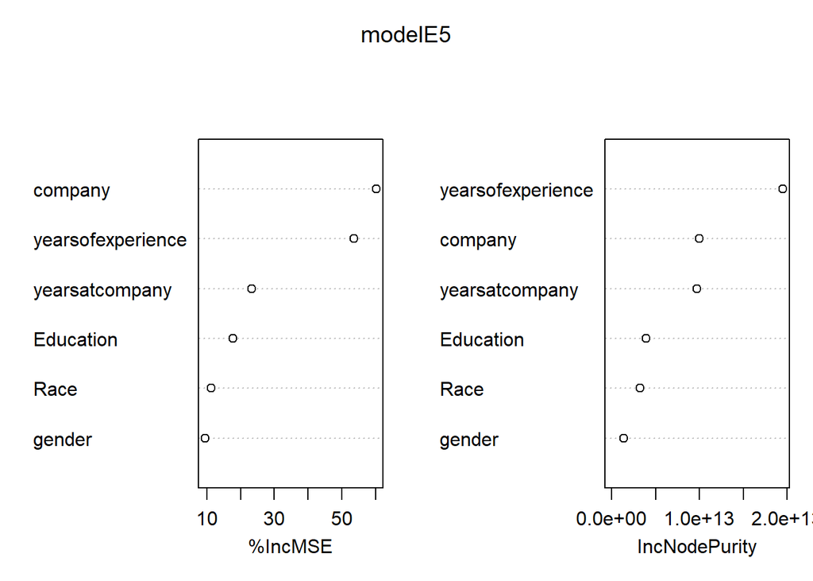

```r
varImpPlot(modelE5)
```

```r
importance(modelE5)
```

```
                    %IncMSE IncNodePurity
company           60.106528  1.001057e+13
yearsofexperience 53.586138  1.947453e+13
yearsatcompany    23.364742  9.735877e+12
gender             9.554184  1.396706e+12
Race              11.391105  3.215284e+12
Education         17.728425  3.940010e+12
```

According to Slide 40 of Lecture 12, a higher increase of node purity indicates that the variable is more important. So, since the highest IncNodePurity belongs to the variable “yearsofexperience”, we can determine that that is the most important variable.

# Exercise 8

```r
p <- ncol(train_data) - 1 # -1 because salary is not a predictor variable but it is one of the columns in train_data
#40965642 * 2 = 81931284
set.seed(81931284)
modelE8 <- randomForest(salary~., data = train_data, ntree = 500, mtry = p, importance = TRUE)
```

# Exercise 9

```r
predictModelE8 <- predict(modelE8, newdata = test_data)
mseE8 <- mean((predictModelE8 - test_data$salary)^2)
rmseE8 <- sqrt(mseE8)
rmseE8
```

```
[1] 146398.5
```

```r
oobmseE8 <- modelE8$mse[length(modelE8$mse)]
oobrmseE8 <- sqrt(oobmseE8)
oobrmseE8
```

```
[1] 110631.9
```

The OOB error is lower than the test error, which is completely normal since the test set is a completely unseen data set.

# Exercise 10

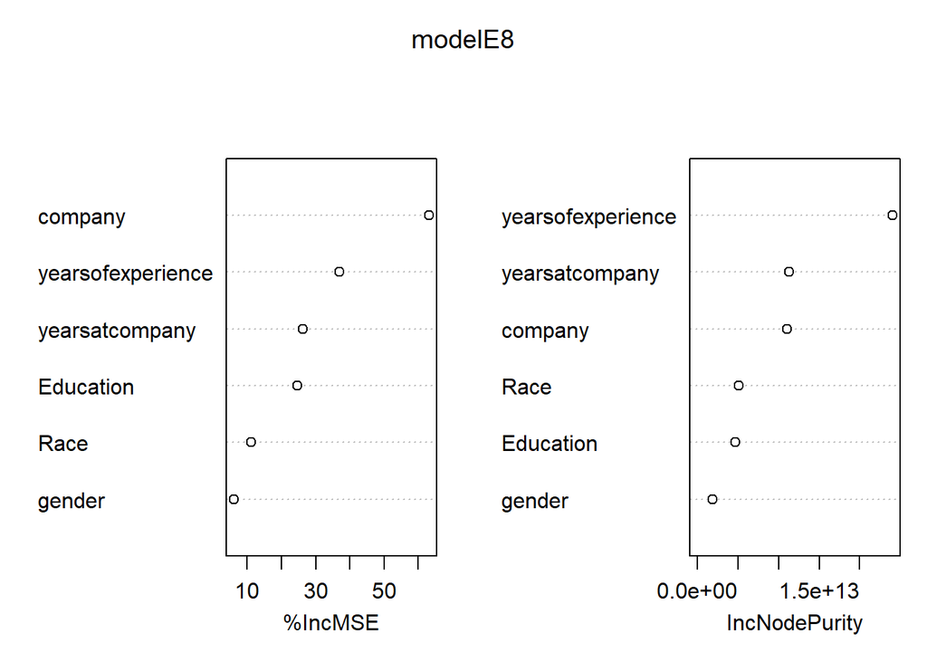

```r
varImpPlot(modelE8)
```

```r
importance(modelE8)
```

```
                    %IncMSE IncNodePurity
company           63.133477  1.103244e+13
yearsofexperience 37.035291  2.402882e+13
yearsatcompany    26.265790  1.126246e+13
gender             6.143105  1.887029e+12
Race              11.209233  5.092261e+12
Education         24.581159  4.645517e+12
```

According to Slide 40 of Lecture 12, a higher increase of node purity indicates that the variable is more important. So, since the highest IncNodePurity belongs to the variable “yearsofexperience”, we can determine that that is the most important variable.

# Exercise 11

```r
mm <- model.matrix(~ . - salary, data = train_data)[, -1]
```

We don’t want to include salary in the matrix, since it is our response variable.

# Exercise 12

```r
modelE12 <- glmnet(mm, train_data$salary, alpha = 0)
modelE12
```

```
Call:  glmnet(x = mm, y = train_data$salary, alpha = 0)

    Df  %Dev   Lambda
1   17  0.00 63850000
2   17  0.23 58180000
3   17  0.25 53010000
4   17  0.28 48300000
5   17  0.30 44010000
6   17  0.33 40100000
7   17  0.37 36540000
8   17  0.40 33290000
9   17  0.44 30330000
10  17  0.48 27640000
11  17  0.53 25180000
12  17  0.58 22950000
```

[output cut: 88 more lines]

```r
summary(modelE12)
```

```
          Length Class     Mode
a0         100   -none-    numeric
beta      1700   dgCMatrix S4
df         100   -none-    numeric
dim          2   -none-    numeric
lambda     100   -none-    numeric
dev.ratio  100   -none-    numeric
nulldev      1   -none-    numeric
npasses      1   -none-    numeric
jerr         1   -none-    numeric
offset       1   -none-    logical
call         4   -none-    call
nobs         1   -none-    numeric
```

# Exercise 13

```r
set.seed(40965642)
cvE12 <- cv.glmnet(mm, train_data$salary, alpha = 0)
minLambda <- cvE12$lambda.min
minLambda
```

```
[1] 6385.121
```

The lowest lambda is the one that has the lowest estimate of error. We will take more lambda values to try to find the true best lambda.

Using default lambda values, the best lambda is 6385.121

## Exercise 12.2

ln(63850000) = 17.97, so we will measure up to e^18. We will go all the way down to e^1 on this iteration to try to find the optimal lambda value.

```r
grid <- exp(seq(18, 1, length = 100))
modelE12b <- glmnet(mm, train_data$salary, alpha = 0, lambda = grid)
modelE12b
```

```
Call:  glmnet(x = mm, y = train_data$salary, alpha = 0, lambda = grid)

    Df  %Dev   Lambda
1   17  0.20 65660000
2   17  0.24 55300000
3   17  0.29 46570000
4   17  0.34 39230000
5   17  0.40 33040000
6   17  0.48 27820000
7   17  0.57 23430000
8   17  0.67 19740000
9   17  0.80 16620000
10  17  0.94 14000000
11  17  1.12 11790000
12  17  1.32  9930000
```

[output cut: 88 more lines]

## Exercise 13.2

```r
set.seed(40965642)
cvE12b <- cv.glmnet(mm, train_data$salary, alpha = 0, lambda = grid)
minLambdab <- cvE12b$lambda.min
minLambdab
```

```
[1] 1854.281
```

I’ve just realized that Exercise 12 states that you should use the default lambda values. I will keep this in anyways to show that the best lambda value will be somewhere around 1854.

# Exercise 14

```r
mmTest <- model.matrix(~ . - salary, data = test_data)[, -1]
predictModelE14 <- predict(modelE12, newx = mmTest, s = minLambda)
mseE14 <- mean((predictModelE14 - test_data$salary)^2)
rmseE14 <- sqrt(mseE14)
rmseE14
```

```
[1] 145355.8
```

# Exercise 15

```r
lambda1se <- cvE12$lambda.1se
predictModelE15 <- predict(modelE12, newx = mmTest, s = lambda1se)
mseE15 <- mean((predictModelE15 - test_data$salary)^2)
rmseE15 <- sqrt(mseE15)
rmseE15
```

```
[1] 150210.2
```

# Exercise 16

```r
modelE16 <- glmnet(mm, train_data$salary, alpha = 1)
```

# Exercise 17

```r
set.seed(40965642)
cvE16 <- cv.glmnet(mm, train_data$salary, alpha = 1)
minLambda16 <- cvE16$lambda.min
minLambda16
```

```
[1] 317.789
```

# Exercise 18

```r
mmTest <- model.matrix(~ . - salary, data = test_data)[, -1]
predictModelE18 <- predict(modelE16, newx = mmTest, s = minLambda)
mseE18 <- mean((predictModelE18 - test_data$salary)^2)
rmseE18 <- sqrt(mseE18)
rmseE18
```

```
[1] 146879.4
```

# Exercise 19

```r
lambda1se16 <- cvE16$lambda.1se
predictModelE19 <- predict(modelE16, newx = mmTest, s = lambda1se)
mseE19 <- mean((predictModelE19 - test_data$salary)^2)
rmseE19 <- sqrt(mseE19)
rmseE19
```

```
[1] 170261
```

# Exercise 20

```r
oobrmseE5 <- round(oobrmseE5)
oobrmseE8 <- round(oobrmseE8)
e20 <- data.frame(
  Model = c("Decision Tree. Exercise 3", "Random Forest. Exercise 5", "Bagging. Exercise 8", "Ridge Regression, Best Lambda. Exercise 14", "Ridge Regression, 1 standard Error. Exercise 15", "LASSO, Best Lambda. Exercise 18", "LASSO, 1 standard error. Exercise 19"),
  TestRMSE = c(rmseE3, rmseE5, rmseE8, rmseE14, rmseE15, rmseE18, rmseE19),
  OOBRMSE = c("N/A", oobrmseE5, oobrmseE8, "N/A", "N/A", "N/A", "N/A")
)
kable(e20)
```

[output not shown]

The random forest performed the best on this data set. It had the lowest test RMSE, which showed that it was the most effective at predicting salary for unseen data points.